# Il variogramma: come si interpreta?

Appunti di geostatistica con R

Autore

Massimo Bressan

data ultima modifica

2025-09-29

# Premessa

Questo breve documento raccoglie alcune domande sul significato e l’interpretazione del *variogramma* che sono emerse durante il corso: “ANALISI GEOSTATISTICA DEI DATI AMBIENTALI – Livello base”, tenuto dal Prof. Pirotti (UniPD) presso ARPAV nel settembre 2025.

Di seguito sono proposte ed illustrate delle tracce di risposta da considerare come possibile esercizio di approfondimento individuale.

```r
# librerie ----------------------------------------------------------------

library(sp)
library(gstat)
library(cowplot) # pkg for easily arranging the plots in a grid

# info geografiche ---------------------------------------------------------

# questa sezione serve per la manipolazione del dataset
# al fine di introdurre l'informazione geografica necessaria per effttuare
# le successive elaborazioni spaziali

data(meuse.grid)
data(meuse)
coordinates(meuse) = ~x+y
coordinates(meuse.grid) = ~x+y
gridded(meuse.grid) = TRUE
```

# Domanda n. 1

### Qual è la differenza tra ‘Variogram Cloud’ vs. ‘Binned Variogram Plot’?

In altri termini viene qui evidenziata la differenza tra:

- il grafico di tipo “cloud plot” per tutte le possibili coppie di punti;
- il grafico “sample variogram” per le medie raggruppate a distanze discrete (binned averages).

Nota bene.

Sono stati utilizzati i valori di default per definire gli argomenti `cutoff` e `width` della funzione `variogram()` (cfr. help online: `?gstat::variogram`).

La scelta dei valori da attribuire agli argomenti `cutoff` e `width` determina il modo in cui vengono “raggruppati e poi mediati” i dati (*esercizio*: sperimenta autonomamente alcune possibili variazioni ai valori di default per “vedere da vicino l’effetto che fa”).

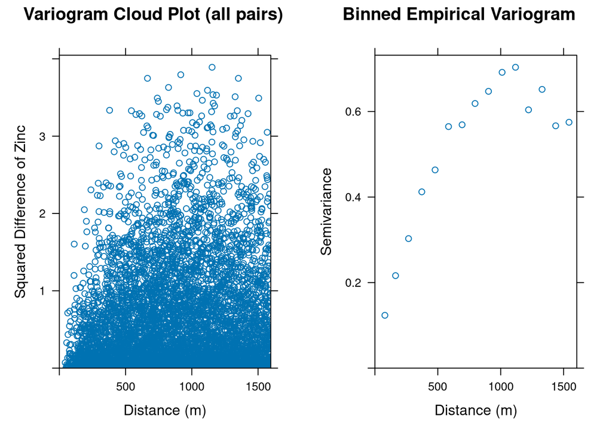

```r
# variogram cloud plot
p1 <- plot(variogram(log(zinc)~1, meuse, cloud = TRUE),
           main = "Variogram Cloud Plot (all pairs)",
           xlab = "Distance (m)",
           ylab = "Squared Difference of Zinc")

# binned average variogram plot
p2 <- plot(variogram(log(zinc)~1, meuse),
           main = "Binned Empirical Variogram",
           xlab = "Distance (m)",
           ylab = "Semivariance")

# arrange plots for comparison
plot_grid(p1, p2, ncol = 2)
```

In sintesi, due tipologie di grafico:

- **Variogram Cloud Plot (plot p1)**: appare tipicamente come una nuvola di punti (cloud) distribuiti nello spazio e mostra un singolo punto per ogni *coppia* di punti geografici; l’asse x rappresenta la distanza tra le coppie di punti mentre l’asse y rappresenta il quadrato delle differenze tra le concentrazioni di zinco per ogni specifica coppia di punti; il grafico è quindi una rappresentazione visuale della distibuzione spaziale di tutte le coppie di punti e serve per individuare eventuali *outliers* (specifiche coppie di punti che deviano significativamente dal trend generale);
- **Binned Empirical Variogram (plot p2)**: è la forma più comune in cui viene visualizzato il *variogramma empirico*; in questo grafico, al posto di rappresentare ogni coppia di punti (ed individuarla con un singolo punto, attenzione a questo particolare che trae spesso in inganno!), in un singolo punto vengono raggruppate tutte le coppie di punti che “cadono” in intervalli di distanza discreti (“bins”) e viene riportata graficamente la media della semi-varianza caratteristica per ciascun “bin”; questa operazione di “raggruppamento” serve sostanzialmente per “lisciare” il grafico di tipo “cloud” e rendere la “sottostante” struttura spaziale dei dati più chiara e facilmente modellabile; il grafico mostra come la dipendenza spaziale cambia con la distanza reciproca tra i punti e da questo grafico è poi possibile “fittare” il modello teorico di variogramma (in un passaggio successivo).

*Domanda:*

*Qual è il significato dei numeri riportati nel grafico “Binned Empirical Variogram”?*

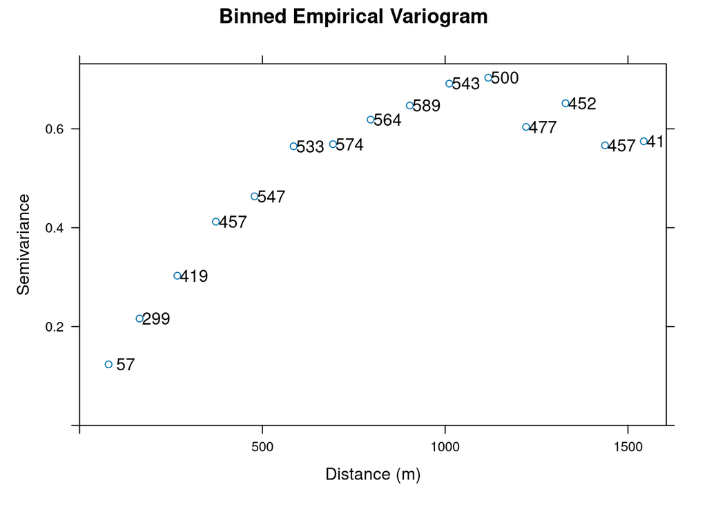

```r
plot(variogram(log(zinc)~1, meuse),
          plot.numbers=TRUE,
          main = "Binned Empirical Variogram",
          xlab = "Distance (m)",
          ylab = "Semivariance")
```

Per la risposta, interpreta i seguenti valori riportati in formato tabellare.

```r
# check against tabular output
variogram(log(zinc)~1, meuse)
```

```
    np       dist     gamma dir.hor dir.ver   id
1   57   79.29244 0.1234479       0       0 var1
2  299  163.97367 0.2162185       0       0 var1
3  419  267.36483 0.3027859       0       0 var1
4  457  372.73542 0.4121448       0       0 var1
5  547  478.47670 0.4634128       0       0 var1
6  533  585.34058 0.5646933       0       0 var1
7  574  693.14526 0.5689683       0       0 var1
8  564  796.18365 0.6186769       0       0 var1
9  589  903.14650 0.6471479       0       0 var1
10 543 1011.29177 0.6915705       0       0 var1
11 500 1117.86235 0.7033984       0       0 var1
12 477 1221.32810 0.6038770       0       0 var1
13 452 1329.16407 0.6517158       0       0 var1
14 457 1437.25620 0.5665318       0       0 var1
15 415 1543.20248 0.5748227       0       0 var1
```

```r
# vs.
head(variogram(log(zinc)~1, meuse, cloud=TRUE), 15)
```

```
        dist        gamma dir.hor dir.ver   id left right
1   70.83784 0.0060658040       0       0 var1    2     1
2  118.84864 0.1095347434       0       0 var1    3     1
3  141.56624 0.1671530948       0       0 var1    3     2
4  259.23927 0.9528082436       0       0 var1    4     1
5  282.85155 1.1109207255       0       0 var1    4     2
6  143.17123 0.4162296643       0       0 var1    4     3
7  366.31407 0.8908527161       0       0 var1    5     1
8  362.64032 1.0439387633       0       0 var1    5     2
9  251.02390 0.3756336724       0       0 var1    5     3
10 154.26276 0.0010412901       0       0 var1    5     4
11 473.62960 0.8335497861       0       0 var1    6     1
12 471.19953 0.9818288051       0       0 var1    6     2
13 356.86692 0.3387579227       0       0 var1    6     3
14 242.15697 0.0039853328       0       0 var1    6     4
15 108.57716 0.0009523684       0       0 var1    6     5
```

*Ulteriori domande*

*Il grafico successivo, che cosa ci racconta? E’ in qualche modo possibile metterlo in relazione con i grafici precedenti?*

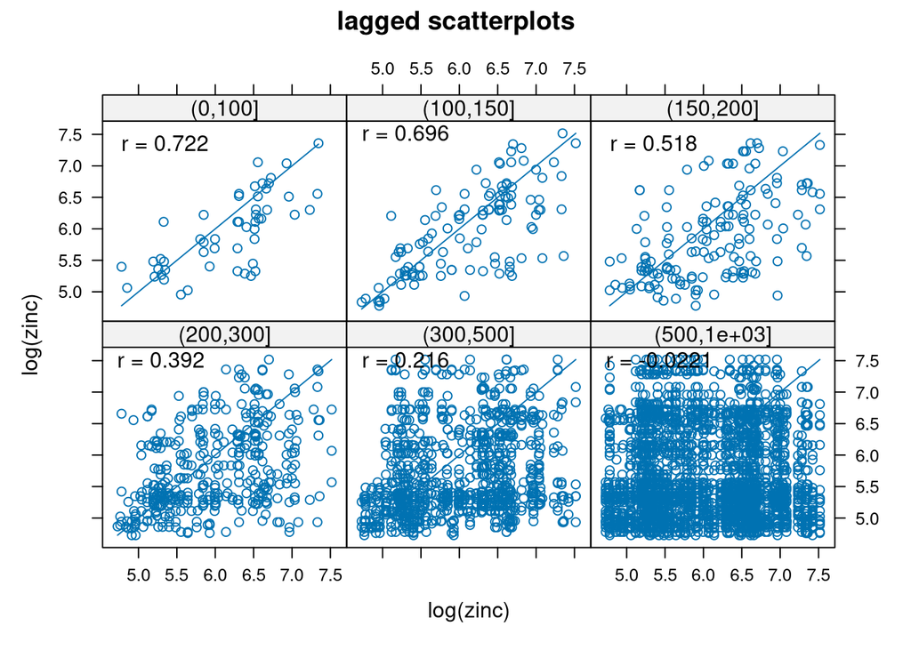

```r
hscat(log(zinc)~1, meuse, c(0, 100, 150, 200, 300, 500, 1000))
```

Pr la risposta, vedi help online `?gstat::hscat`

# Domanda n. 2

### Come si interpreta il variogramma di una variabile ed una covariata?

Viene qui spiegato come il variogramma di una variabile e di una covariata equivale al variogramma dei residui dopo la rimozione del trend.

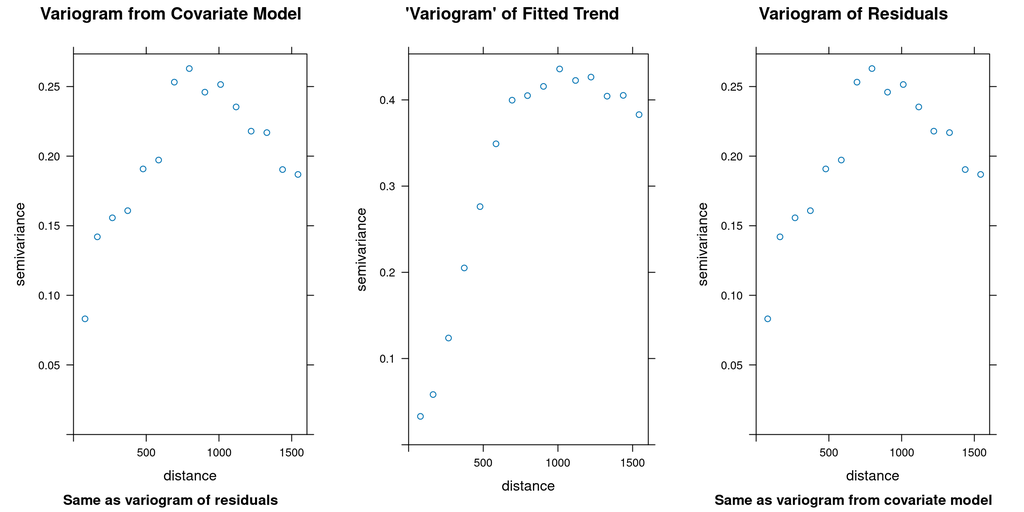

```r
# plot variogram of residuals directly using the covariate formula
p3 <- plot(variogram(log(zinc)~sqrt(dist.m), meuse),
           main = "Variogram from Covariate Model",
           sub = "Same as variogram of residuals")

# TO BE NOTED: dist.m IS NOT the distance between all pair points
# which is instead calculated by the variogram
# but it is very simply another variable (covariate): i.e the distance form the river
# there is no special meaning in this variable with regard to the distance of all pair points
# that is used in the calculation of the variogram

# linear regression to manually separate trend and residuals
lm_model <- lm(log(zinc)~sqrt(dist.m), data=meuse)

# add fitted values (the trend) to the data frame
meuse$trend <- fitted.values(lm_model)

# plot the "variogram" of the fitted values (the trend)
# Note: This does not represent spatial autocorrelation
p4 <- plot(variogram(trend~1, meuse),
           main = "'Variogram' of Fitted Trend")

# add residuals to the data frame
meuse$residuals <- residuals(lm_model)

# double check, trivial indeed
#all.equal(residuals(lm_model), log(meuse$zinc)-fitted.values(lm_model))
#all.equal(fitted.values(lm_model), log(meuse$zinc)-residuals(lm_model))

# plot variogram of residuals
p5 <- plot(variogram(residuals~1, meuse),
           main = "Variogram of Residuals",
           sub = "Same as variogram from covariate model")

# arrange the three plots to show mutual relationship
plot_grid(p3, p4, p5, ncol = 3)
```

*Il codice sopra riportato rende evidente come nel caso venga inclusa una covariata nella formula del variogramma (e.g., log(zinc)~sqrt(dist.m)) la successiva analisi spaziale viene effettuata sui residui*.

Questa caratteristica individua chiaramente due tipiche componenti nella struttura spaziale dei dati ambientali:

1 - la *componente deterministica* (della media, o del trend) che è, in questo caso specifico, una funzione composta dalla variabile “zinco” e la covariata “distanza dal fiume”; questa è la parte del dato che può essere spiegata da un modello di regressione lineare;

2 - la *componente stocastica* (dei residui) che è la parte di autocorrelazione spaziale che “residua” dopo la rimozione del trend.

*Nota che il variogramma con la covariata (plot p3) è identico al variogramma dei residui (plot p5) ottenuti dalla regressione lineare.*

Il pacchetto gstat quando viene “alimentato” con una formula che prevede la trattazione di una covariata per prima cosa effettua “internamente” una regressione lineare per modellare il trend (la componente deterministica - la media!) e successivamente calcola il variogramma sui residui (della nuova variabile di fitting).

In definitiva queste evidenze confermano che la parte di dipendenza spaziale (autocorrelazione) del dataset viene sostanzialmente analizzata nei residui (!) e non nel trend (media).

Attenzione:

il variogramma dei valori di fitting (plot p4) mostra il trend (parte deterministica) e quindi non si tratta di un variogramma nel senso tradizionale perchè questo:

- NON rappresenta l’autocorrelazione spaziale;
- MA rappresenta la varianza spiegata dalla covariata considerata.

# Domanda n. 3

### Considerato quanto visto in precedenza, come si interpreta la formula nel variogramma di una singola variabile? Che cosa indica quella notazione particolare “`~1`”?

Cerchiamo ora di esplorare in dettaglio come avviene il processo di calcolo di un variogramma per una singola variabile autocorrelata, in modo da avere un’idea più precisa e chiara sul comportamento interno della funzione `variogram()` del pacchetto `gstat`.

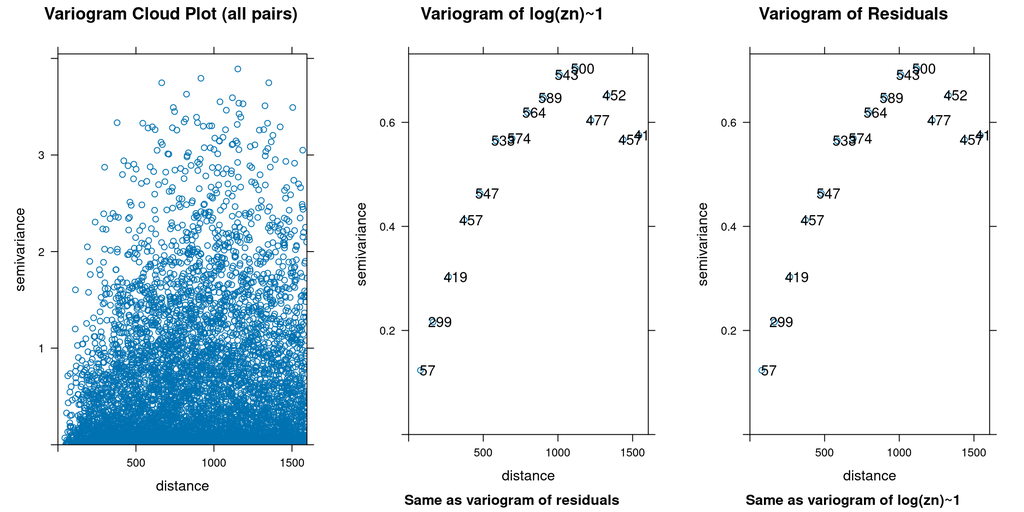

```r
# linear regression to manually separate trend and residuals
# in fact this is just the model mean of Zn (log transformed!)
zn <- lm(log(zinc)~1, data=meuse)

# add fitted values (the trend) to the data frame
meuse$res_zn<-residuals(zn)

p6 <- plot(variogram(log(zinc)~1, meuse, cloud=TRUE),
           main = "Variogram Cloud Plot (all pairs)")

p7 <- plot(variogram(log(zinc)~1, meuse),
           plot.numbers=TRUE,
           main = "Variogram of log(zn)~1",
           sub = "Same as variogram of residuals")

p8 <- plot(variogram(res_zn~1, meuse),
           plot.numbers=TRUE,
           main = "Variogram of Residuals",
           sub = "Same as variogram of log(zn)~1")

plot_grid(p6, p7, p8, ncol = 3)
```

```r
# double check the value of the mean, virtually zero
r<-lm(res_zn~1, data = meuse)
round(mean(r$coefficients,6))
```

```
[1] 0
```

```r
round(mean(meuse$res_zn),6)
```

```
[1] 0
```

```r
dplyr::near(mean(r$coefficients), mean(meuse$res_zn))
```

```
[1] TRUE
```

I grafici p7 e p8 restituiscono esattamente la stessa informazione ma ricavata da una base di partenza differente.

Da rilevare che il valore medio dei residui (scarti dalla media) è virtualmente pari a zero (per definizione).

# Note finali su `lm()`

Quando viene definito un modello lineare utilizzando la notazione del tipo `lm(var~1)` stiamo imponendo a R di fittare un modello costituito dalla sola intercetta, senza l’impiego di altri predittori.

Riferendoci all’esempio precedente il modello matematico che viene fittato è il seguente:

$$y_i = \beta_0+\epsilon_i$$
dove:

- $y_i$ è il valore della variabile zinco per l’osservazione $i$
- $\beta_0$ è il valore dell’intercetta
- $\epsilon_i$ è l’errore per l’osservazione $i$

In questo semplice modello, lo stimatore (“Best Linear Unbiased Estimator - BLUE)” per il valore dell’intercetta $\beta_0$ è semplicemente rappresentato dalla media aritmetica della variabile risposta (concentrazioni di zinco, log trasformate).

In sintesi l’espressione in R:

- `lm(log(zinc)~1, data=meuse)`

serve per “fittare” un “modello nullo”, cioè un modello costituito dalla sola intercetta. E questa notazione , nell’ambito dei modelli lineari, rappresenta un modo formale per calcolare il valore medio di una variabile.

Analogamente, l’espressione in R:

- `lm(log(zinc)~sqrt(dist.m), data=meuse)`

serve per “fittare” una equazione lineare del tipo:

$$y_i = \beta_0+\beta_1 \cdot x_i + \epsilon_i$$
dove, considerando l’esempio precedente:

- $y_i$ è sono le concentrazioni (log-trasformate) di zinco per l’osservazione $i$
- $\beta_0$ è l’intercetta, cioè la concentrazione di zinco quando la variabile $x_i$ (distanza dal fiume, trasformata con radice quadrata) è pari a zero
- $\beta_1$ è il coefficiente angolare cioè la stima della variazione di concentrazione di zinco per ogni unità di incremento di $x_i$
- $x_i$ è il valore della variabile distanza al fiume per l’osservazione $i$
- $\epsilon_i$ è il termine errore (residuo) per l’osservazione $i$

In termini non formali, con la formula precedente stiamo “chiedendo” a R di trovare la retta di “best fitting” che descrive come le concentrazioni di zinco variano con la distanza dal fiume (cioè la variabile predittiva considerata).